# Tarea 4

Jose Aguilar, Eilyn Salazar, Crisia Piedra

5/16/2020

# Entendimiento del negocio

Para esta tarea se hará uso de la siguiente página https://en.wikipedia.org/wiki/List_of_highest-grossing_video_game_franchises, la cual muestra las franquicias de video juegos con mayores ingresos.

El objetivo de negocio que se propone es identificar los clusteres o grupos en los que se ubican las diferentes compañias basados en sus ingresos y por año.

# Entendimiento de los datos

La página seleccionada para realizar este análisis “List of highest-grossing video game franchises” está estructurada en 5 secciones:

- Sección 1: Introducción en donde se explica el contenido de la página. El cuál es el mostrar el listado de compañías de juegos más rentables agrupados en 4 grandes grupos basado en el rango de ingresos en los que se encuentra cada franquicia, ya sean 10,5,2 o 1 millón de dólares
- Sección 2: Detalle de los ingresos (Tablas). Para cada grupo se muestra una tabla la cual muestra el nombre de la Franquicia (Franchise), el año de creación (Year of inception), los ingresos de por vida (Lifetime revenue), Desglose de ingresos (Revenue breakdown), Dueño de la franquicia (Franchise owner), Plataforma Original (Original platforms), Genero Original (Original genre)
- Sección 3: Temas relacionados: URLs a sitios que contienen información relacionada a la página seleccionada.
- Sección 4: Notas.
- Sección 5: Referencias.

Para efectos del trabajo se hará uso únicamente de la sección 2, a continuación se presenta la caracterización de los atributos incluidos en cada tabla.

```r
atributos<-read.csv('atributos.csv', sep = ',',dec = '.')
kable(atributos[,0:4],caption = "Descripción de los atributos")%>%
kable_styling(bootstrap_options = c("striped", "hover"))
```

Descripción de los atributos

| Atributo | Descripción | Tipo | Ejemplo |
| --- | --- | --- | --- |
| Franchise | Nombre de la franquicia | Alfanuméricos | Wii |
| Year of inception | Año de creación de la compañía | Alfanuméricos | 2006 |
| Lifetime revenue | Estimación de los ingresos totales en billones incluyendo el año hasta el cual se consideran los datos | Alfanuméricos | est. $14.808 billion (as of 2018) |
| Revenue breakdown | Columna compuesta, incluye el nombre del juego de la franquicia o rango de años de la liberación de versiones del juego, ylos ingresos en billones de dólares | Alfanuméricos | Wii Sports – $6.08 billion[104] Wii Fit – $5 billion[51] Other games – $3.728 billion[l] |
| Franchise owner(s) | Dueño de la franquicia | Alfanuméricos | Nintendo |
| Original platform(s) | Plataforma | Alfanuméricos | Wii |
| Original genre(s) | Genero del juego | Alfanuméricos | Simulation (Sports) Exergaming |

## Exploración de los datos

Se procede a realizar la extracción de los datos de cada tabla, los cuales se almacenarán en las variables, datos10m, datos5m, datos2m and datos1m.

```r
dirPag<-'https://en.wikipedia.org/wiki/List_of_highest-grossing_video_game_franchises'
pag<- read_html(dirPag,encoding = 'UTF-8')

# se extraen específicamente las tablas que contenga la página
tablasPag<- html_table(pag,fill=TRUE)
#length(tablasPag)
#tablasPag

# Se obtienen las 4 tablas que agrupan los juegos de la compañia por cada uno de los juegos
datos10m<- tablasPag[[1]]
datos5m<- tablasPag[[2]]
datos2m<- tablasPag[[3]]
datos1m<- tablasPag[[4]]

# Se procede a añadir una columna categoria, para unir los valores de las tablas en un solo dataset.
datos10m['Categoria'] <- '10m'
datos5m['Categoria'] <- '5m'
datos2m['Categoria'] <- '2m'
datos1m['Categoria'] <- '1m'

#Se unen todos los dataframes en una sola.
datos <- rbind(datos10m,datos5m,datos2m,datos1m)
```

```r
summary(datos)
```

```
##   Franchise         Year of inception  Lifetime revenue   Revenue breakdown
##  Length:84          Length:84          Length:84          Length:84
##  Class :character   Class :character   Class :character   Class :character
##  Mode  :character   Mode  :character   Mode  :character   Mode  :character
##  Franchise owner(s) Original platform(s) Original genre(s)   Categoria
##  Length:84          Length:84            Length:84          Length:84
##  Class :character   Class :character     Class :character   Class :character
##  Mode  :character   Mode  :character     Mode  :character   Mode  :character
```

## Verificación de la calidad de datos

Al explorar los datos es posible ver que no hay valores nulos o NAs. Con respecto a la normalización de los datos, se observan oportunidades de normalización de atributos como “Revenue breakdown”, por ejemplo la franquicia “Mario”, tiene agrupados sus ingresos en 3 juegos “Super Mario”, “Mario Cart” y “Otros Mario games”, sin embargo en el caso de “Call of Duty” los ingresos están agrupados por rangos de años o año, ejemplo: “2003-2017”, “2018” y “2019”.

# Preparación de los datos

## Selección de los datos

Para efectos del trabajo se excluirá unicamente la columna Revenue Breakdown

```r
#Se remueve la columna Revenue Breakdown
datos<-datos[,-4]
colnames(datos)
```

```
## [1] "Franchise"            "Year of inception"    "Lifetime revenue"
## [4] "Franchise owner(s)"   "Original platform(s)" "Original genre(s)"
## [7] "Categoria"
```

```r
#Se renombran las nombres de las columnas
colnames(datos)<-c('Franquicia','Anno','Ingresos','Duenno','Plataforma','Genero', 'Categoria')
#datos
```

## Limpieza de los datos

Para el proceso de limpieza de datos se hizo uso de expresiones regulares para eliminar caracteres o palabras clave como: “$”, “est.” o realizar conversiones de datos a continuación se presentan las transformaciones realizadas.

Para el atributo Ingresos se aplicaron las siguientes transformaciones.

```r
#Se elimina el símbolo $ y el texto est. y billions del campo Revenue
revenue<- str_remove(datos$Ingresos,'est\\.')
revenue<- str_remove(revenue,'\\s*\\$')
revenue<- str_remove(revenue,' billion.*$')
# Se convierte el atributo ingresos a un dato de tipo numérico y se multiplica por el valor billón.
revenue<- as.numeric(revenue)#*1000000000
datos$Ingresos<-revenue
```

Para el atributo Genero se aplicaron las siguientes transformaciones: Dejamos solamente el primer genero en el que fue clasificada la franquicia.

```r
genres<-datos$Genero
genres<- str_remove(genres,' .*$')
datos$Genero <- genres
```

Para el atributo Plataforma se aplicaron las siguientes transformaciones: Dejamos solamente la primera plataforma en la que apareció la franquicia.

```r
platfrom<-datos$Plataforma
platfrom<- str_remove(platfrom,' /.*$')
platfrom<- str_remove(platfrom,'Comm.*$')
platfrom<- str_remove(platfrom,'HandheldPC.*$')
platfrom<- str_remove(platfrom,'PlayStationPC$')
platfrom<- str_remove(platfrom,'^IBM ')
platfrom<- str_replace(platfrom,'PlayStation 3Xbox 360','PlayStation 3')
platfrom<- str_replace(platfrom,'PS4Xbox OnePC','PS4')
datos$Plataforma<-platfrom
```

## Construcción de nuevos datos (atributos)

Se creó un atributo nuevo llamado “Categoría” el cual es de tipo factor y fue usado para identificar el grupo al que pertenecen las franquicias basado en sus ingresos por billones. La creación de este atributo se realizó en la sección “Exploración de los datos”, ya que fue necesario combinar los resultados de los datos originales para su limpieza y análisis.

## Transformaciones aplicadas a los datos

Se convierten los atributos a tipos de dato factor y numeric según corresponda.

```r
# Se realiza la conversión de atributos

#Copia de los datos originales
datosSinTransformaciones <- datos

datos$Franquicia <- as.factor(datos$Franquicia)
datos$Anno <- as.numeric(datos$Anno)
datos$Duenno <- as.factor(datos$Duenno)
datos$Plataforma <- as.factor(datos$Plataforma)
datos$Genero <- as.factor(datos$Genero)
datos$Categoria <- as.factor(datos$Categoria)
#str(datos)
#head(datos)

#Se utiliza la función omit para excluir cualquier valor NA. Sin embargo como se mencionó anteriormente basado en una revisión preliminar de los datos no hay valores nulos.
datosFinal<-na.omit(datos)
head(datosFinal)
```

```
##       Franquicia Anno Ingresos
## 1          Mario 1981   32.400
## 2        Pokémon 1996   19.533
## 3   Call of Duty 2003   18.132
## 4            Wii 2006   14.808
## 5        Pac-Man 1980   14.107
## 6 Space Invaders 1978   13.930
##                                                                      Duenno
## 1                                                                  Nintendo
## 2 Nintendo (trademark) The Pokémon Company(Nintendo, Game Freak, Creatures)
## 3                                                                Activision
## 4                                                                  Nintendo
## 5                                                Bandai Namco Entertainment
## 6                                                      Taito  (Square Enix)
##   Plataforma     Genero Categoria
## 1     Arcade Platformer       10m
## 2   Game Boy        RPG       10m
## 3         PC    Shooter       10m
## 4        Wii Simulation       10m
## 5     Arcade     Action       10m
## 6     Arcade    Shooter       10m
```

# Fase de modelado

## Selección de técnicas

Para esta tarea se hará uso de las técnicas de agrupamiento Kmedias y Kmedoids a fin de comprar los resultados de ambas técnicas usando diferentes parámetros de K.

## Construcción de cada modelo.

### Construcción del modelo #1 (Kmedoids)

Para el modelo #1 se hace uso de la técnica Kmedoids.

### Selección de los parámetros modelo #1 (Kmedoids)

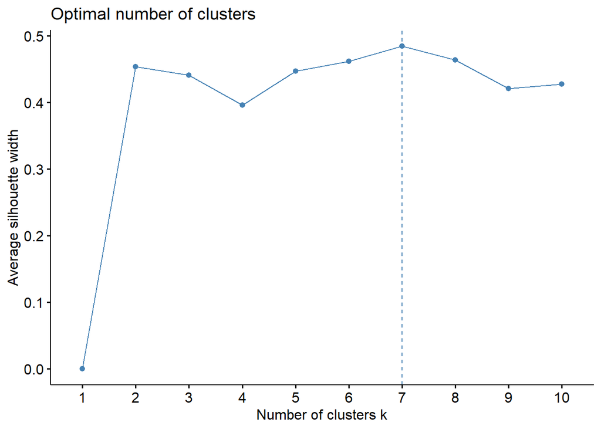

```r
# cálculo del score Silhouette
#score_sil<- silhouette(clusters_kmedoids,daisy(datosFinal))

# cálculo del valor óptimo de k usando el score silhouette
fviz_nbclust(datosFinal[,2:3],pam,method = 'silhouette',k.max = 10)
```

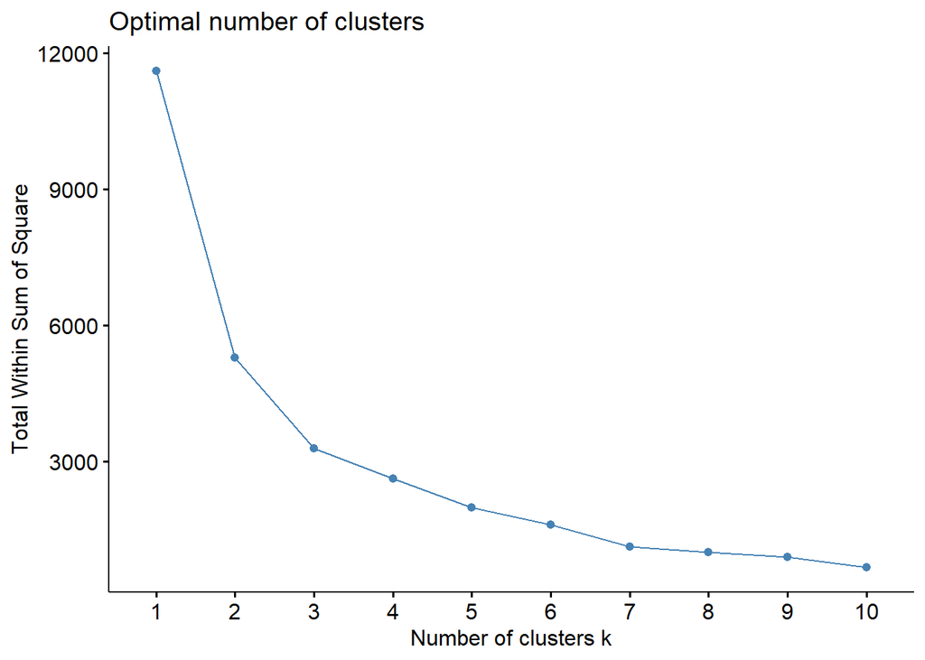

```r
# cálculo del valor óptimo de k usando el método del codo
fviz_nbclust(datosFinal[,2:3],pam,method = 'wss',k.max = 10)
```

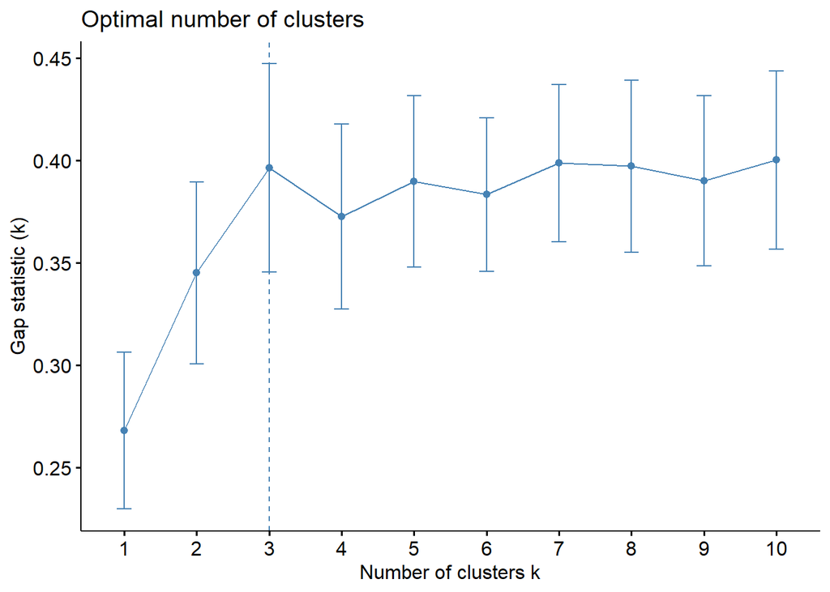

```r
# cálculo del valor óptimo de k usando la estadística gap
fviz_nbclust(datosFinal[,2:3],pam,method = 'gap_stat',k.max = 10)
```

### Ejecución modelo #1

```r
# generar los clusters usando kmedoids
# datosRenombrados <- datosFinal
row.names(datosFinal)<-datosFinal$Franquicia
clusters_kmedoids<-pam(datosFinal[,2:3],4)


# crear un data frame combinando el cluster asignado y los atributos originales
resultado_medoids <- data.frame(clusters_kmedoids$cluster,datosFinal[2:3])
head(resultado_medoids)
```

```
##                clusters_kmedoids.cluster Anno Ingresos
## Mario                                  1 1981   32.400
## Pokémon                                2 1996   19.533
## Call of Duty                           3 2003   18.132
## Wii                                    3 2006   14.808
## Pac-Man                                1 1980   14.107
## Space Invaders                         1 1978   13.930
```

```r
#resultado_medoids %>% arrange((resultado_medoids$clusters_kmedoids.cluster))
```

Al analizar el valor de los medoides obtenidos por los cluster observamos como con respecto a los ingresos vemos valores de 6.22, 3.77, 3.00 y 1.5, en el caso de los clusteres que incluyen los años de 1996 y 2003, se aprecia que la diferencia en torno a los ingresos es muy cercana, en este caso si se desearan crear clusteres basados en los ingresos podrian manejarse ya sean 4 o 3 grupos, incluyendo franquicias que tengan ingresos entre 3 y 4 billones.

```r
clusters_kmedoids$medoids
```

```
##                            Anno Ingresos
## Dragon Ball                1986    6.226
## Resident Evil  (Biohazard) 1996    3.777
## MapleStory                 2003    3.004
## Disney Tsum Tsum           2014    1.500
```

### Descripción del modelo obtenido (Incluya al menos un gráfico)

En el siguiente modelo podemos observar los 4 clusters creados,

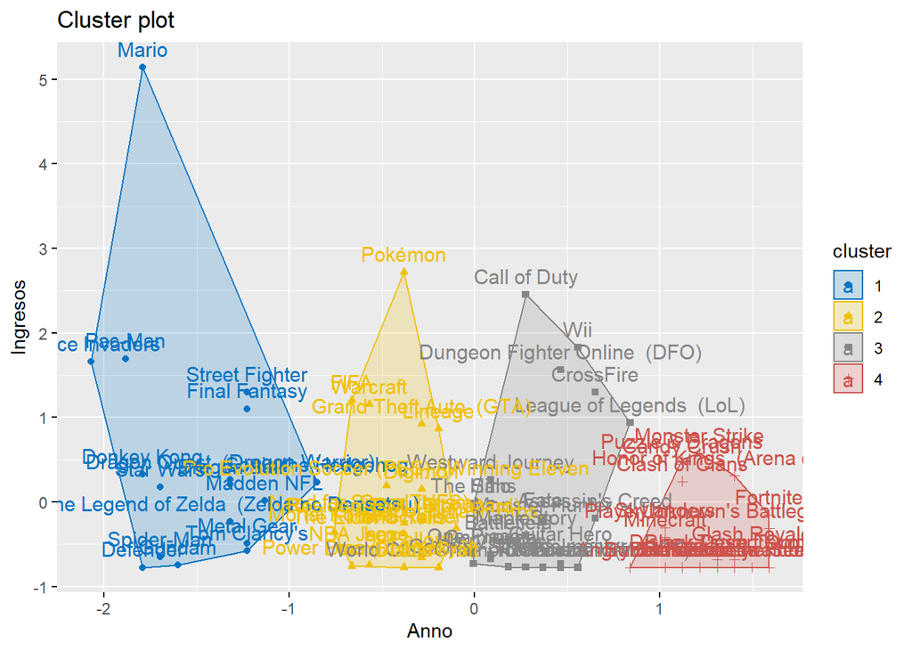

```r
# visualización de los clusters
fviz_cluster(clusters_kmedoids,data=datosFinal,palette='jco')
```

```r
# cluster al que se asignó cada individuo
clusteres_medoids <- clusters_kmedoids$clustering
#clusteres_medoids
# Descripción de los clusters
medoids <- clusters_kmedoids$medoids
medoids
```

```
##                            Anno Ingresos
## Dragon Ball                1986    6.226
## Resident Evil  (Biohazard) 1996    3.777
## MapleStory                 2003    3.004
## Disney Tsum Tsum           2014    1.500
```

Al analizar el gráfico anterior es posible apreciar como los clusteres creados por el algoritmo kmedoids, parecen identificar agrupar franquicias que fueron creadas en años o periodos de tiempo cercanos.

### Construcción del modelo #2 (Kmedias)

Para el modelo #2 se hace uso de la técnica Kmedias.

### Selección de los parámetros modelo #2 (Kmedias)

Para el segundo modelo se analizarán se usan unicamente las variables numéricas Año e Ingresos.

Para determinar el número de clusteres óptimo se analizan los 3 métodos vistos en clase, y luego de analizar los diferentes resultados, así como los resultados del número optimo para el algoritmo de kmedoids, se propone hacer uso de un k=4 a fin de comparar los resultados de los modelos.

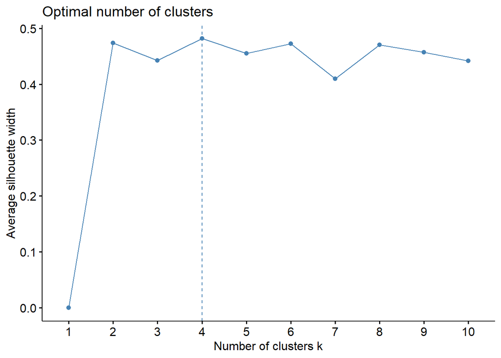

```r
# cálculo del score Silhouette
#score_sil<- silhouette(clusters$cluster,daisy(d))

# cálculo del valor óptimo de k usando el score silhouette
fviz_nbclust(datosFinal[,2:3],kmeans,method = 'silhouette',k.max = 10)
```

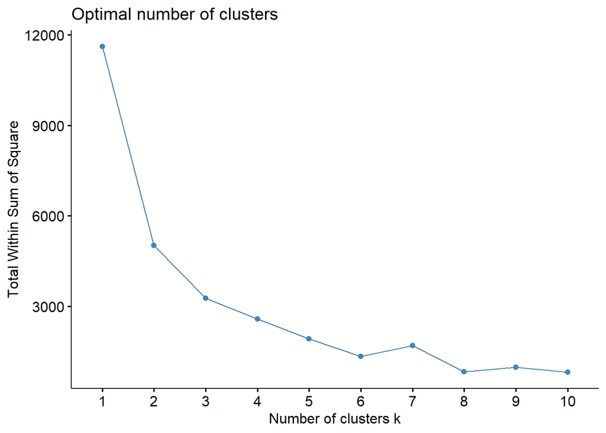

```r
# cálculo del valor óptimo de k usando el método del codo
fviz_nbclust(datosFinal[,2:3],kmeans,method = 'wss',k.max = 10)
```

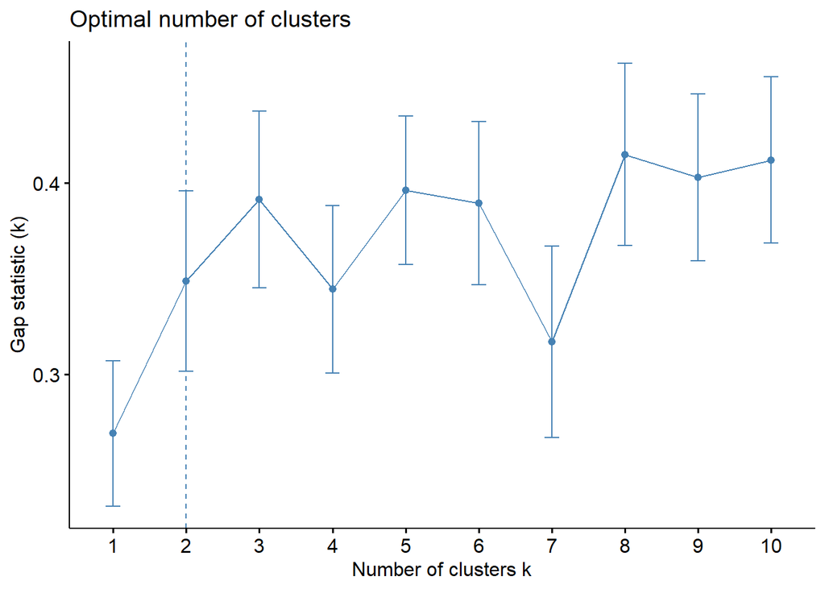

```r
# cálculo del valor óptimo de k usando la estadística gap
fviz_nbclust(datosFinal[,2:3],kmeans,method = 'gap_stat',k.max = 10)
```

### Ejecución modelo #2

```r
clusters <- kmeans(datosFinal[,2:3],4,nstart=20)
clusteres_kmeans <- clusters$cluster

# crear un data frame combinando el cluster asignado y los atributos originales
resultado_kmeans <- data.frame(clusters$cluster,datosFinal[,2:3])
head(resultado_kmeans)
```

```
##                clusters.cluster Anno Ingresos
## Mario                         2 1981   32.400
## Pokémon                       2 1996   19.533
## Call of Duty                  2 2003   18.132
## Wii                           2 2006   14.808
## Pac-Man                       3 1980   14.107
## Space Invaders                3 1978   13.930
```

```r
#resultado_kmeans %>% arrange((resultado_kmeans$clusters.cluster))
```

```r
#obtener cantidad de registros en cada cluster y los centroides
descClusters<- data.frame(clusters$size,clusters$centers)
descClusters
```

```
##   clusters.size     Anno  Ingresos
## 1            34 1999.206  2.692118
## 2            10 1998.000 15.268000
## 3            16 1984.500  6.271813
## 4            23 2013.043  3.430435
```

### Descripción del modelo obtenido (Incluya al menos un gráfico)

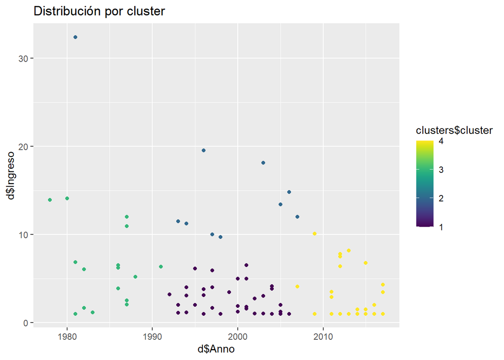

```r
d <- datosFinal[,2:3]
ggplot(d,aes(d$Anno,d$Ingreso, color = clusters$cluster)) + geom_point()+ggtitle(label='Distribución por cluster') +
  scale_color_viridis(option = "D")
```

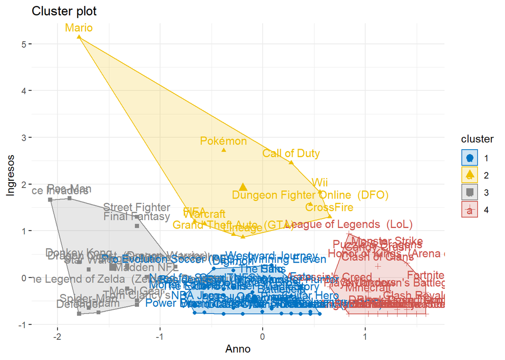

```r
# otra forma de visualizar los clusters
fviz_cluster(clusters,data=d[,c(1,2)],palette='jco',ggtheme = theme_minimal())
```

En el caso del algoritmo de kmeans, los clusteres creados se encuentran más asociados a los ingresos generados por ejemplo podemos ver como Franquicias como Mario, Pokemón y Call of Duty parecen tener comportamientos similares de ingresos y y son franquicias que se han mantenido a lo largo de los años. Las mismas fueron agrupadas en el grupo 2. En el caso de los grupos 1, 3 y 4, tienen un comportamiento similar a los clusteres generados por el método kmedoids y distribuir las franquicias a lo largo de determinados años.

## Evaluación de los modelos

### Comparación de los resultados obtenidos los modelos.

A fin de comparar los resultados de los clusteres generados por ambos métodos se genera la siguiente tabla de comparación.

```r
clusteres_medoidsr <- data.frame(Franquicia = names(clusteres_medoids), clusteres_medoids)
resultados_kmd <- merge(x=datosFinal,y=clusteres_medoidsr, by="Franquicia")

resultados_kmd_ordenados <- resultados_kmd %>% select('Franquicia','Anno','clusteres_medoids','Ingresos') %>% arrange(desc(resultados_kmd$clusteres_medoids))
```

```r
clusteres_medoidsr <- data.frame(Franquicia = names(clusteres_medoids), clusteres_medoids)
clusteres_kmeansr <- data.frame(Franquicia = names(clusteres_kmeans), clusteres_kmeans)

resultados_kmd <- merge(x=datosFinal,y=clusteres_medoidsr, z=clusteres_kmeansr, by="Franquicia")
resultados_kmd <- merge(x=resultados_kmd,y=clusteres_kmeansr, by="Franquicia")

resultado_final_Anno <- resultados_kmd %>%
  select('Franquicia','Categoria','Anno','clusteres_medoids','clusteres_kmeans') %>%
  arrange(desc(resultados_kmd$Anno))

resultado_final_Categoria <- resultados_kmd %>%
  select('Franquicia','Categoria','Anno','clusteres_medoids','clusteres_kmeans') %>%
  arrange(desc(resultados_kmd$Categoria))

kable(head(resultado_final_Anno,10),"html", booktabs = T)%>%  kable_styling(latex_options = "striped")
```

| Franquicia | Categoria | Anno | clusteres_medoids | clusteres_kmeans |
| --- | --- | --- | --- | --- |
| Fortnite | 2m | 2017 | 4 | 4 |
| Garena Free Fire | 1m | 2017 | 4 | 4 |
| PlayerUnknown’s Battlegrounds (PUBG) | 2m | 2017 | 4 | 4 |
| Clash Royale | 2m | 2016 | 4 | 4 |
| Overwatch | 1m | 2016 | 4 | 4 |
| Black Desert Online | 1m | 2015 | 4 | 4 |
| Heroes of the Storm | 1m | 2015 | 4 | 4 |
| Honor of Kings (Arena of Valor) | 5m | 2015 | 4 | 4 |
| Destiny | 1m | 2014 | 4 | 4 |
| Disney Tsum Tsum | 1m | 2014 | 4 | 4 |

```r
#kable(head(resultado_final_Categoria,10),"html", booktabs = T)%>%  kable_styling(latex_options = "striped")
```

```r
library(plyr)
conteos_medoids <- ddply(resultado_final_Categoria, .(resultado_final_Categoria$Categoria, resultado_final_Categoria$clusteres_medoids), nrow)
names(conteos_medoids) <- c("Categoria", "clusteres_medoids", "Conteo")
kable(conteos_medoids,"html", booktabs = T,caption = "Conteos de pares de Categoría asignada de wikipedia y cluster asignado por kmedoids") %>%
  kable_styling(bootstrap_options="striped")
```

Conteos de pares de Categoría asignada de wikipedia y cluster asignado por kmedoids

| Categoria | clusteres_medoids | Conteo |
| --- | --- | --- |
| 10m | 1 | 5 |
| 10m | 2 | 3 |
| 10m | 3 | 5 |
| 1m | 1 | 3 |
| 1m | 2 | 5 |
| 1m | 3 | 10 |
| 1m | 4 | 11 |
| 2m | 1 | 3 |
| 2m | 2 | 9 |
| 2m | 3 | 6 |
| 2m | 4 | 5 |
| 5m | 1 | 6 |
| 5m | 2 | 4 |
| 5m | 3 | 3 |
| 5m | 4 | 5 |

Como podemos observar, para cada categoria de wikipedia, el algoritmo de k-medoids dsitribuyó las observaciones en los diferentes clusters de forma repartida, sin una clara tendencia.

```r
conteos_kmeans <- ddply(resultado_final_Categoria, .(resultado_final_Categoria$Categoria, resultado_final_Categoria$clusteres_kmeans), nrow)
names(conteos_kmeans) <- c("Categoria", "clusteres_kmeans", "Conteo")
kable(conteos_kmeans,"html", booktabs = T,caption = "Conteos de pares de Categoría asignada de wikipedia y cluster asignado por kmeans") %>%
  kable_styling(bootstrap_options="striped",)
```

Conteos de pares de Categoría asignada de wikipedia y cluster asignado por kmeans

| Categoria | clusteres_kmeans | Conteo |
| --- | --- | --- |
| 10m | 2 | 8 |
| 10m | 3 | 4 |
| 10m | 4 | 1 |
| 1m | 1 | 15 |
| 1m | 3 | 3 |
| 1m | 4 | 11 |
| 2m | 1 | 14 |
| 2m | 3 | 3 |
| 2m | 4 | 6 |
| 5m | 1 | 5 |
| 5m | 2 | 2 |
| 5m | 3 | 6 |
| 5m | 4 | 5 |

A diferenciad e k-medoids, parece que k-means para cada categoria de wikipedia, el algoritmo distribuyó las observaciones en los diferentes clusters pero en menor grado (opr ejemplo, todas las categorias excepto la 5m solo se distribuyen a 3 clusters en vez de 4) y en cada categoria existe un cluster predominante al que asigna las observaciones (excepto en el cluster 5):

[output not shown]